# Practical ML - Prediction Assignment Writeup

Piotr Patrzałek

7 lutego 2019

### Pre processing

My goal is to predict classe variable. I would like to start with some pre-processing things, because many of variables probably don’t have high predictive power. I think that good idea is to drop them.

## 1. Load dataset

Firstly, I set directory and load training and testing data. Next i used `dplyr` package to drop some columns. I think that, that kind of variables aren’t neccesary in my dataset.

```r
setwd("C:/Users/ppatrzalek/Desktop/Coursera/Practical Machine Learning/")
training_original <- read.csv("pml-training.csv", sep = ",", header = TRUE)
testing_original <- read.csv("pml-testing.csv", sep = ",", header = TRUE)

library(dplyr)
training <- training_original %>%
  select(-c("raw_timestamp_part_1", "raw_timestamp_part_2", "cvtd_timestamp", "num_window", "X", "user_name"))

testing <- testing_original %>%
  select(-c("raw_timestamp_part_1", "raw_timestamp_part_2", "cvtd_timestamp", "num_window", "X", "user_name"))
```

## 2. Near Zero Variance

I used `nearZeroVar()` function to drop columns which probably can’t help me to predict “classe” variable. These variables have very low variance value so I think that it’s a good idea to drop them at the moment.

```r
library(caret)
training_nzv <- nearZeroVar(training, saveMetrics = TRUE)
nzv <- which(training_nzv$nzv == TRUE)
training <- training[,-nzv]; testing <- testing[,-nzv]
```

## 3. NA variables

My next step was to get rid of variables with almost NA values. I think that predictors where are almost 95% of NA’s values aren’t valuable.

```r
library(tidyr)
na.variables <- function(data){
  n_column <- ncol(data)
  n_rows <- nrow(data)
  na_columns <- c()
  for(i in 1:n_column){

    if (length(which(is.na(data[,i]) == TRUE))/n_rows > 0.95) na_columns[i] <- i

  }
  which(is.na(na_columns) == FALSE)
}

na_variables <- na.variables(training)
training <- training[,-na_variables]; testing <- testing[,-na_variables]
```

## 4. Correlation predictors

After 1-3 steps of my analysis I have not 160 variables but only 60. Now I will try to calculate correlation between predictors and plot them. In my opinion if some predictors have high correlation then I can use only one of them. We will see how many predictors I can drop. I use only pearson correlation because it is most common metric and I would try to find some linear dependencies.

```r
correlation_variables <- training %>%
  select(-classe)

high_correlation_predictors <- function(data, value){
  results_matrix <- as.matrix(cor(data, method = "pearson"))
  results <- data.frame(row = rownames(results_matrix)[row(results_matrix)],
                        col = colnames(results_matrix)[col(results_matrix)],
                        corr = c(results_matrix))
  results <- results %>%
    filter(corr != 1)

  results %>%
    filter(abs(corr) > value )
}

correlation_variables2 <- high_correlation_predictors(correlation_variables, 0.9)
```

Below I add correlation values between very associated variables.

Correlation between variables

| row | col | corr |
| --- | --- | --- |
| total_accel_belt | roll_belt | 0.9809241 |
| accel_belt_y | roll_belt | 0.9248983 |
| accel_belt_z | roll_belt | -0.9920085 |
| accel_belt_x | pitch_belt | -0.9657334 |
| roll_belt | total_accel_belt | 0.9809241 |
| accel_belt_y | total_accel_belt | 0.9278069 |
| accel_belt_z | total_accel_belt | -0.9749317 |
| pitch_belt | accel_belt_x | -0.9657334 |
| roll_belt | accel_belt_y | 0.9248983 |
| total_accel_belt | accel_belt_y | 0.9278069 |
| accel_belt_z | accel_belt_y | -0.9333854 |
| roll_belt | accel_belt_z | -0.9920085 |
| total_accel_belt | accel_belt_z | -0.9749317 |
| accel_belt_y | accel_belt_z | -0.9333854 |
| gyros_arm_y | gyros_arm_x | -0.9181821 |
| gyros_arm_x | gyros_arm_y | -0.9181821 |
| gyros_dumbbell_z | gyros_dumbbell_x | -0.9789507 |
| gyros_forearm_z | gyros_dumbbell_x | -0.9144764 |
| gyros_dumbbell_x | gyros_dumbbell_z | -0.9789507 |
| gyros_forearm_z | gyros_dumbbell_z | 0.9330422 |
| gyros_dumbbell_x | gyros_forearm_z | -0.9144764 |
| gyros_dumbbell_z | gyros_forearm_z | 0.9330422 |

After correlation analysis i decided to drop columns which you see below:

```r
correlation_belt <- high_correlation_predictors(select(correlation_variables, contains("belt")), 0.9)
drop_belt <- as.vector.factor(distinct(correlation_belt, col)[2:6,1])

correlation_arm <- high_correlation_predictors(select(correlation_variables, contains("arm")), 0.9)
drop_arm <- c("gyros_arm_y")

correlation_dumbbell <- high_correlation_predictors(select(correlation_variables, contains("dumbbell")), 0.9)
drop_dumbbell <- c("gyros_dumbbell_z")

training <- training %>%
  select(-c(drop_belt, drop_arm, drop_dumbbell))

testing <- testing %>%
  select(-c(drop_belt, drop_arm, drop_dumbbell))
```

### Modelling

I try two models: decision trees and random forest. For those models I trade on `caret` package. It’s more easygoing for machine learnig problems. Before I create models I have to split training set into new training and testing dataset in proportions 70/30.

```r
inTrain <- createDataPartition(y = training$classe, p = 0.7, list = FALSE)

training_model <- training[inTrain,]
testing_model <- training[-inTrain,]
```

## 1. Decision trees

Firstly, I prepare decision tree. For create fance plot I use `rattle` package.

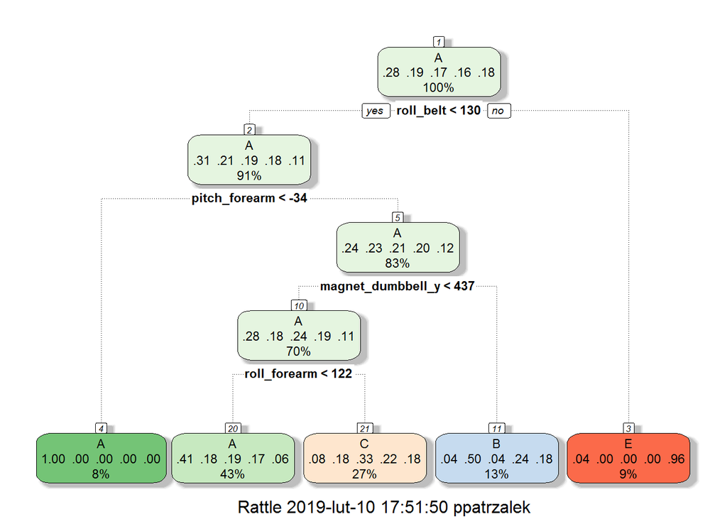

```r
set.seed(123)
modelFitTree <- train(classe ~., method = "rpart", data = training_model)

library(rattle)
fancyRpartPlot(modelFitTree$finalModel)
```

Then I check accuracy on my new testing data set.

```r
new_classe_testing_trees <- predict(modelFitTree, testing_model)
conf_matrix_trees <- confusionMatrix(new_classe_testing_trees, testing_model$classe)
print(conf_matrix_trees)
```

```
## Confusion Matrix and Statistics
##
##           Reference
## Prediction    A    B    C    D    E
##          A 1496  464  488  421  149
##          B   27  389   37  151  139
##          C  124  286  501  392  277
##          D    0    0    0    0    0
##          E   27    0    0    0  517
##
## Overall Statistics
##
##                Accuracy : 0.4933
##                  95% CI : (0.4804, 0.5061)
##     No Information Rate : 0.2845
##     P-Value [Acc > NIR] : < 2.2e-16
##
##                   Kappa : 0.3384
##  Mcnemar's Test P-Value : NA
##
## Statistics by Class:
##
##                      Class: A Class: B Class: C Class: D Class: E
## Sensitivity            0.8937   0.3415  0.48830   0.0000  0.47782
## Specificity            0.6386   0.9254  0.77794   1.0000  0.99438
## Pos Pred Value         0.4957   0.5236  0.31709      NaN  0.95037
## Neg Pred Value         0.9379   0.8541  0.87805   0.8362  0.89421
## Prevalence             0.2845   0.1935  0.17434   0.1638  0.18386
## Detection Rate         0.2542   0.0661  0.08513   0.0000  0.08785
## Detection Prevalence   0.5128   0.1263  0.26848   0.0000  0.09244
## Balanced Accuracy      0.7661   0.6335  0.63312   0.5000  0.73610
```

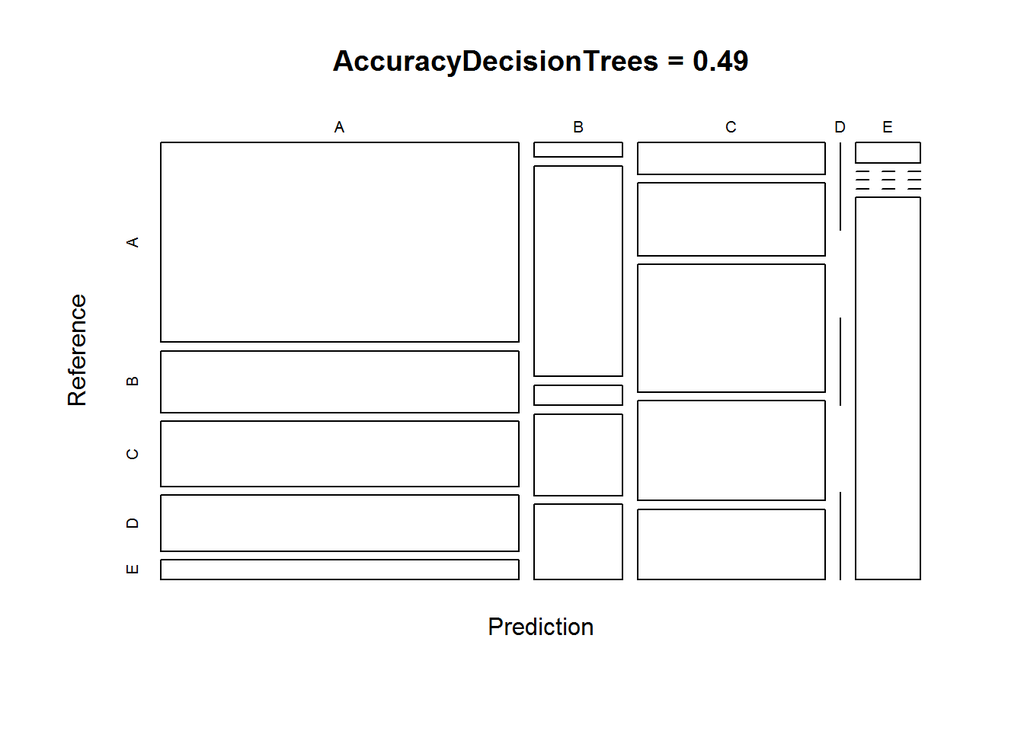

```r
plot(conf_matrix_trees$table, col = conf_matrix_trees$byClass,
     main = paste("AccuracyDecisionTrees =",
                  round(conf_matrix_trees$overall['Accuracy'], 2)))
```

## 2. Random Forest

This model achive the highest accuracy. How you see below this model reach almost 100% accuracy on testing dataset. It could be strange that this model have such a good results. Of course in training dataset it could be overfitting but for testing dataset I think that this acurracy is OK.

```r
set.seed(123)
library(randomForest)
modelFitRandomForest <- train(classe ~., method = "rf", data = training_model, ntree = 10,
                              trControl = trainControl(method = "repeatedcv",
                                                       number = 10,
                                                       repeats = 10,
                                                       classProbs = TRUE
                                                       ))

new_classe_testing_rf <- predict(modelFitRandomForest, testing_model)
conf_matrix_rf <- confusionMatrix(new_classe_testing_rf, testing_model$classe)
print(conf_matrix_rf)
```

```
## Confusion Matrix and Statistics
##
##           Reference
## Prediction    A    B    C    D    E
##          A 1666   13    0    3    0
##          B    4 1119    7    1    6
##          C    2    4 1014   16    1
##          D    0    1    5  942    6
##          E    2    2    0    2 1069
##
## Overall Statistics
##
##                Accuracy : 0.9873
##                  95% CI : (0.9841, 0.99)
##     No Information Rate : 0.2845
##     P-Value [Acc > NIR] : < 2.2e-16
##
##                   Kappa : 0.9839
##  Mcnemar's Test P-Value : 0.009543
##
## Statistics by Class:
##
##                      Class: A Class: B Class: C Class: D Class: E
## Sensitivity            0.9952   0.9824   0.9883   0.9772   0.9880
## Specificity            0.9962   0.9962   0.9953   0.9976   0.9988
## Pos Pred Value         0.9905   0.9842   0.9778   0.9874   0.9944
## Neg Pred Value         0.9981   0.9958   0.9975   0.9955   0.9973
## Prevalence             0.2845   0.1935   0.1743   0.1638   0.1839
## Detection Rate         0.2831   0.1901   0.1723   0.1601   0.1816
## Detection Prevalence   0.2858   0.1932   0.1762   0.1621   0.1827
## Balanced Accuracy      0.9957   0.9893   0.9918   0.9874   0.9934
```

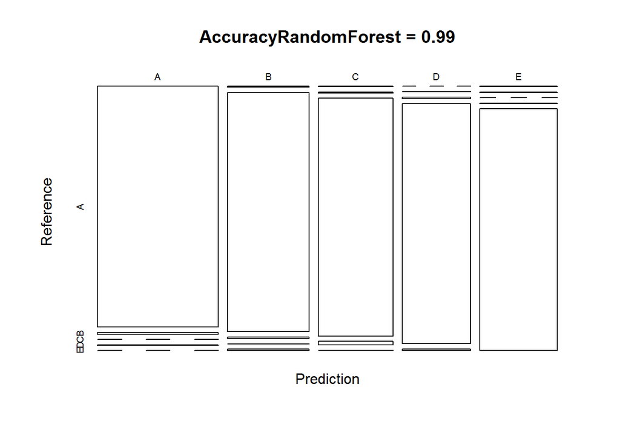

```r
plot(conf_matrix_rf$table, col = conf_matrix_rf$byClass,
     main = paste("AccuracyRandomForest =",
                  round(conf_matrix_rf$overall['Accuracy'], 2)))
```

### Prediction

I chosen the Random Forest model because it achive the highest value of accuracy. Results of my prediction on the original testing data set I present below:

```r
predict_classe <- predict(modelFitRandomForest, testing)
print(predict_classe)
```

```
##  [1] B A B A A E D B A A B C B A E E A B B B
## Levels: A B C D E
```